# MASZ - Projekt 8 Sieci hierarchiczne, warstwowe i czasowe

Ryszard Szymański

5/6/2020

# Zadania wykładowe

## Zadanie 1

Przygotowano funkcję przygotowującą ramkę danych z zależnością $C(k)$ (funkcja `prepare_clustering_coeff_to_degree_relation_data`) oraz odpowiednią funkcję `plot_clustering_coeff_to_degree_relation` to wizualizacji:

```r
prepare_clustering_coeff_to_degree_relation_data
```

```
## function (graph)
## {
##     data.frame(clustering_coeff = transitivity(graph, type = "local"),
##         degrees = degree(graph))
## }
```

```r
plot_clustering_coeff_to_degree_relation
```

```
## function (data, include_theoretical_curve)
## {
##     if (include_theoretical_curve) {
##         data$type <- "real"
##         theoretical_data <- data.frame(degrees = data$degrees,
##             clustering_coeff = 1/data$degrees, type = "theory")
##         data <- bind_rows(data, theoretical_data)
##         ggplot(data, aes(x = degrees, y = clustering_coeff, color = type,
##             group = type)) + geom_point()
##     }
##     else {
##         ggplot(data, aes(x = degrees, y = clustering_coeff)) +
##             geom_point()
##     }
## }
```

## Zadanie 2

Sprawdzono następujące sieci: * [cit-DBLP](http://networkrepository.com/cit-DBLP.php) - sieć cytowań * rec-amazon - sieć wspólnie kupowanych produktów na Amazonie * [insecta-ant-colony1](http://networkrepository.com/insecta-ant-colony1.php) - sieć kontaktów w kolonii mrówek

Narysowany wykresy zależności współczynnika gronowania od stopnia wierzchołka dla wszystkich 3 grafów. W celu weryfikacji czy punkty dopasowują się zgodnie z oczekiwaniami do zależności $C(k) \sim k^{-1}$ narysowano dodatkowym kolorem wartości funkcji $f(k) = k^{-1}$.

### cit-DBLP

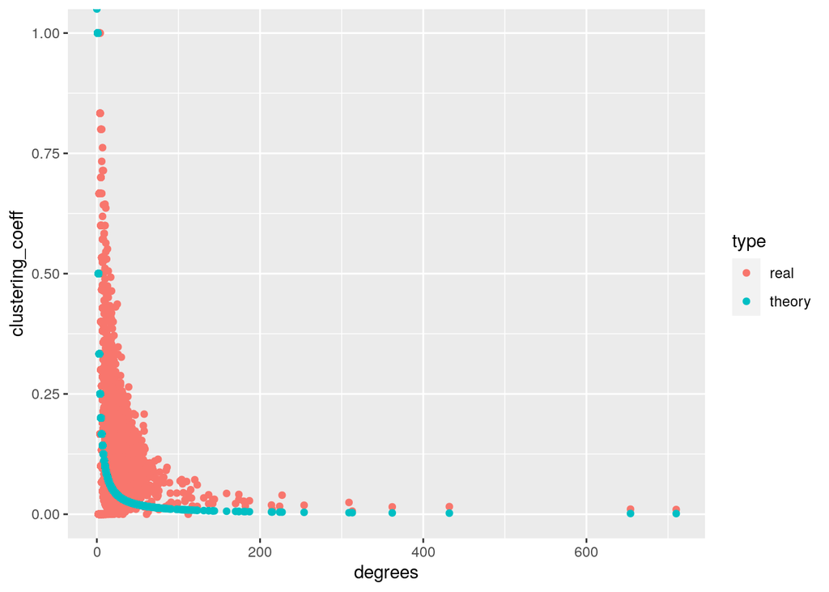

```r
drake::readd(plot_data_cit_dlbp_graph)
```

### rec-amazon

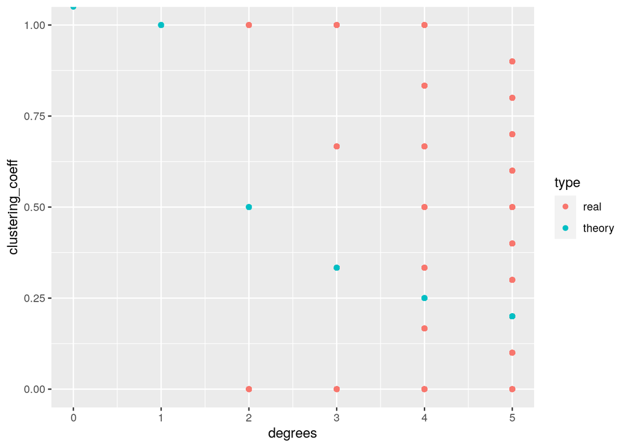

```r
drake::readd(plot_data_rec_amazon_graph)
```

### insecta-ant-colony

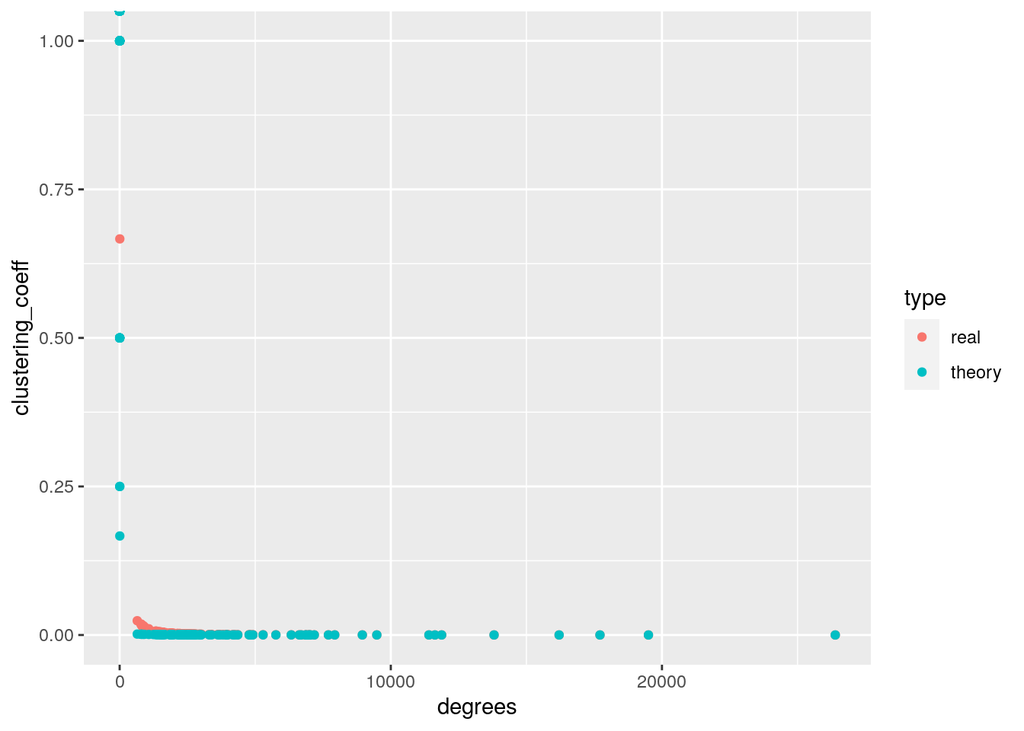

```r
drake::readd(plot_data_ant_colony_graph)
```

Na podstawie powyższych wykresów można zauważyć, że sieć cytowań oraz sieć kolonii mrówek są hierarchicznie, co pokrywa się z oczekiwaniami. Sieć cytowań z powodów wspomianych na wykładzie a w przykładzie kolonii mrówek naturalna jest hierarchia: królowa, robotnice i inni. W przypadku sieci wspólnie kupowanych produktów na amazonie taka zależność nie występuje, aczkolwiek trudno tutaj interpretować wykres, ponieważ występuje tam wiele wierzchołków o bardzo niskich stopniach:

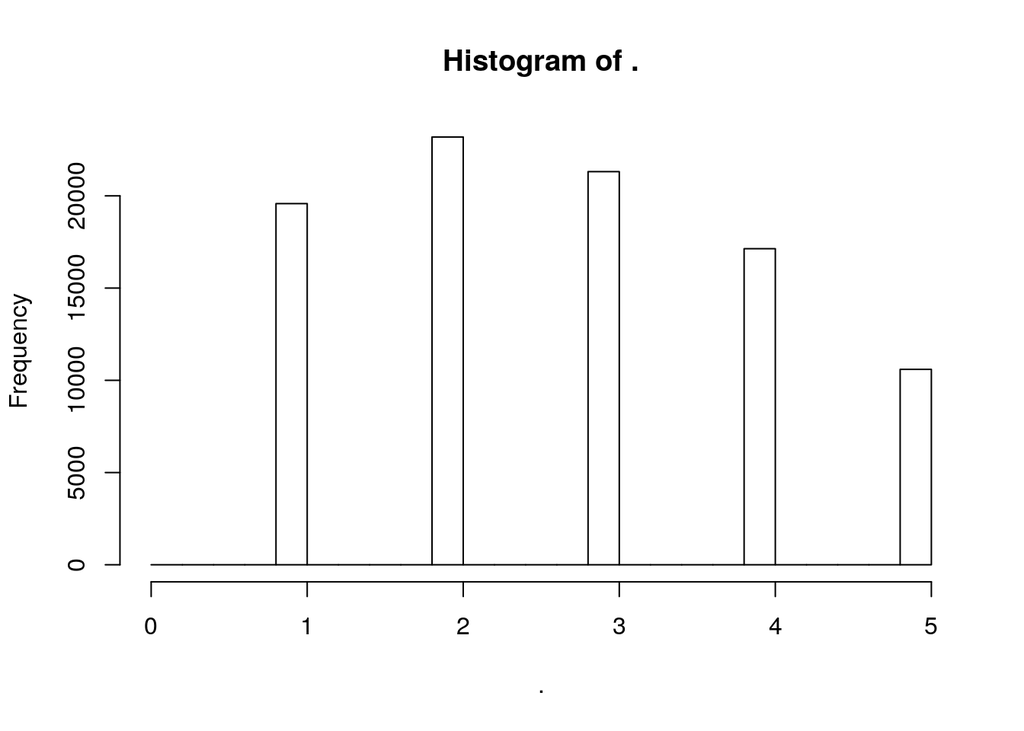

```r
drake::readd(rec_amazon_graph) %>% degree() %>% hist()
```

## Zadanie 3 i 4

Wykorzystano pojedyńczy plik z dostępnych danych rozkładowych. Przeparsowane metadatane przystanków oraz drogi wszystkich linii transportowych w celu utworzenia grafu. Zastosowano następującą regułe łączenia wierzchołków: jeśli dwa przystanki występują w jakiejkolwiek drodze bezpośrednio po sobie to są one połączone krawędzią. Rodzaj krawędzi (kolejowy, tramwajowy czy autobusowy) określano na podstawie rodzaju przystanków łączących dane krawędzie.

### Linie autobuse

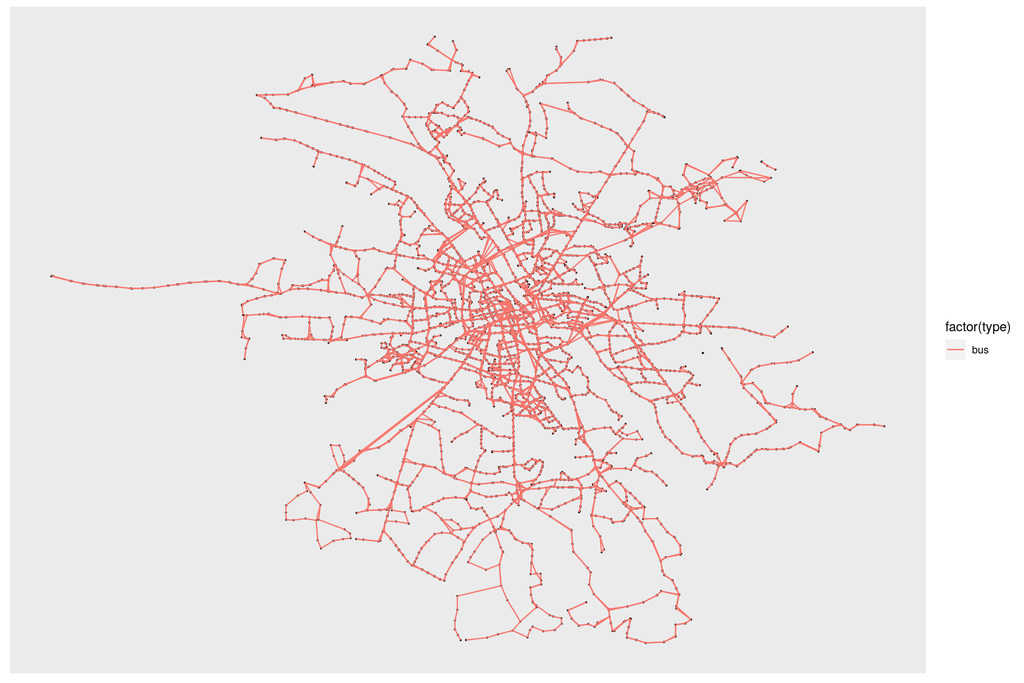

```r
drake::readd(transport_graph_layer_plot_bus)
```

```r
drake::readd(transport_graph_layer_summary_bus) %>%
  knitr::kable()
```

| Licza.wierzchołków | Liczba.krawędzi | Spójność | Średni.stopień.wierzchołka | Współczynnik.gronowania |
| --- | --- | --- | --- | --- |
| 5844 | 7668 | FALSE | 2.62423 | 0.0380905 |

### Linie tramwajowe

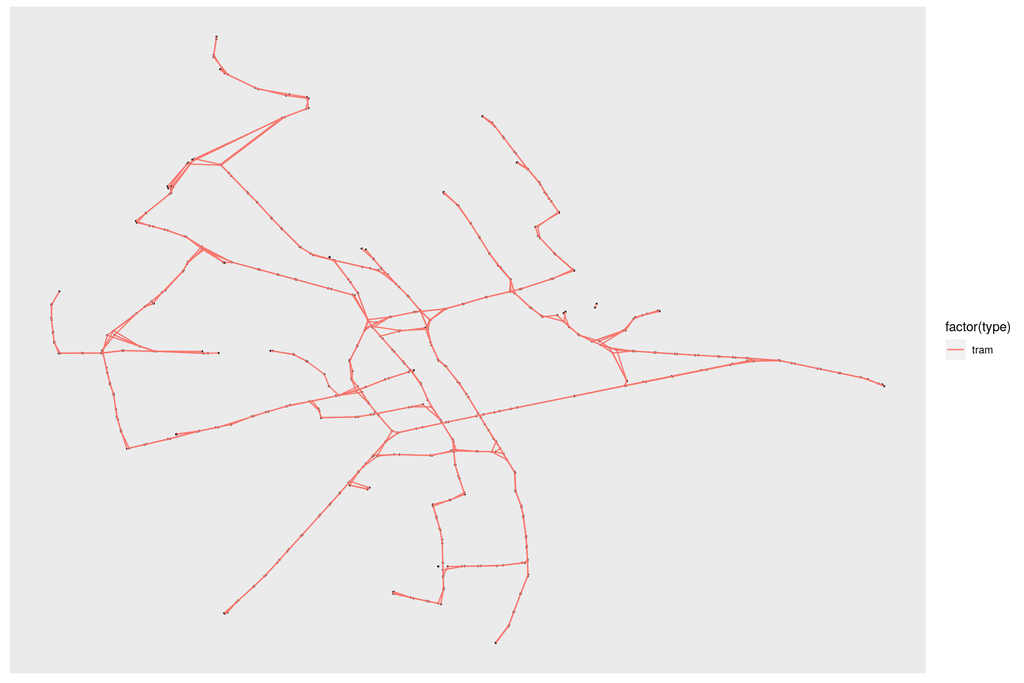

```r
drake::readd(transport_graph_layer_plot_tram)
```

```r
drake::readd(transport_graph_layer_summary_tram) %>%
  knitr::kable()
```

| Licza.wierzchołków | Liczba.krawędzi | Spójność | Średni.stopień.wierzchołka | Współczynnik.gronowania |
| --- | --- | --- | --- | --- |
| 546 | 603 | FALSE | 2.208791 | 0 |

### Linie pociągów

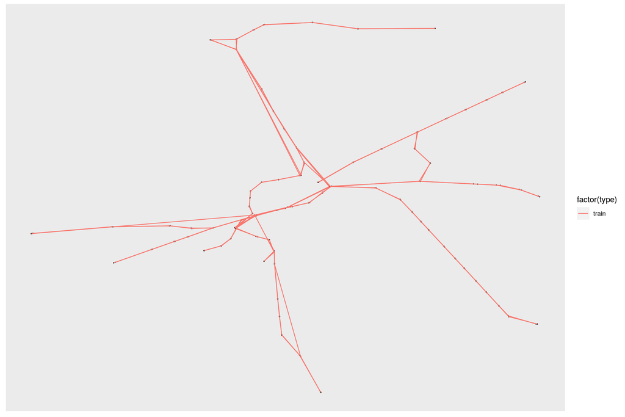

```r
drake::readd(transport_graph_layer_plot_train)
```

```r
drake::readd(transport_graph_layer_summary_train) %>%
  knitr::kable()
```

| Licza.wierzchołków | Liczba.krawędzi | Spójność | Średni.stopień.wierzchołka | Współczynnik.gronowania |
| --- | --- | --- | --- | --- |
| 171 | 185 | FALSE | 2.163743 | 0.0581395 |

### Sieć warstwowa

```r
drake::readd(transport_graph_summary) %>%
  knitr::kable()
```

| Licza.wierzchołków | Liczba.krawędzi | Spójność | Średni.stopień.wierzchołka | Współczynnik.gronowania |
| --- | --- | --- | --- | --- |
| 6561 | 8456 | FALSE | 2.577656 | 0.0364238 |

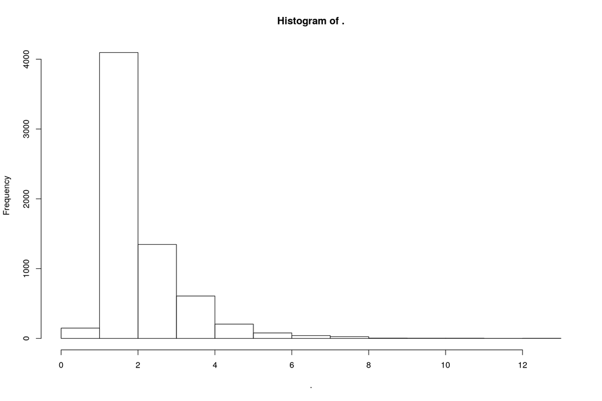

```r
drake::readd(transport_graph)$graph %>%
  degree() %>%
  hist()
```

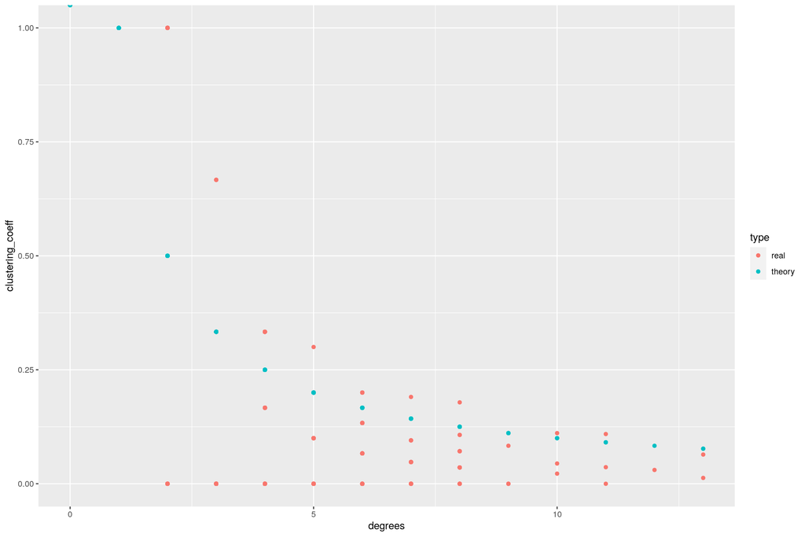

```r
drake::readd(transport_graph_layer_plottt)
```

Na podstawie powyższych podsumowań i wykresów można zauważyć, że:

- Warstwa “autobusowa” stanowi zdecydowaną więkość całej sieci
- Większość wierzchołków ma stopień równy 2 – są środkowym elementem trasy
- Uzyskana sieć transportowa wykazuje “cechy” warstwowości – niska różnorodność stopni wierzchołkach utrudnia odczytanie wykresu

## Zadanie 5

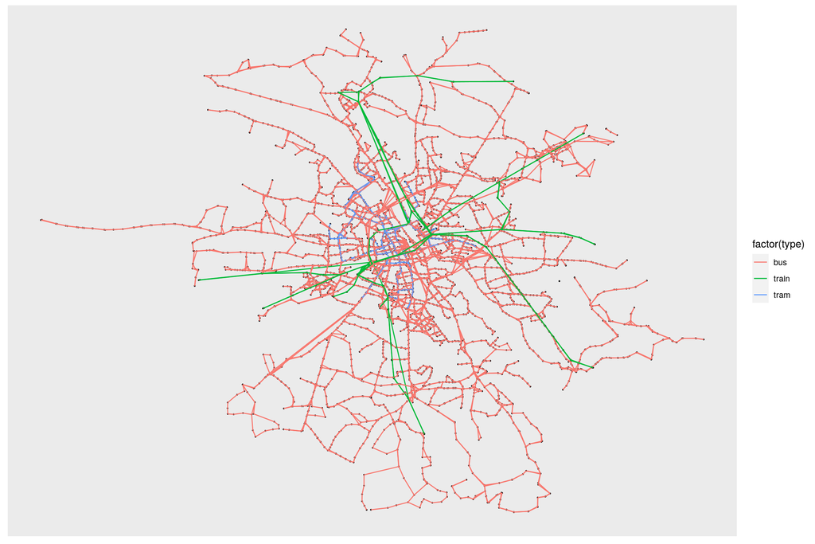

```r
drake::readd(transport_graph_plot)
```

## Zadanie 6

Po sparsowaniu danych rozkładów obliczono liczbę autobusów odwiedzających przystanek w odstępach godzinowych. Sieć następowania budowano w taki sposób, żeby uwzględniano jedynie wierzchołki odwiedzane w danym odstępie czasowym.

## Zadanie 7

Na animacji przedstawiono sieć transportową dla każdego godzinnego odstępu czasowego. Kolorem wierzchołka oznaczono jak wiele linii odwiedza dany przystanek.

```r
knitr::include_app("animation.gif")
```

[interactive chart not shown]

## Zadanie 8

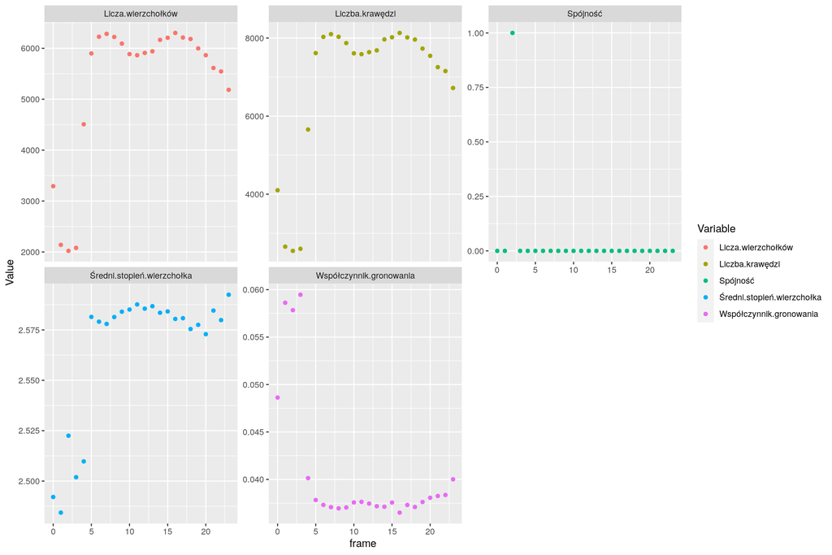

```r
drake::readd(transport_graph_summary_over_time_plot)
```

Na podstawie animacji oraz wykresu z zadań 7/8 można zauważyć:

- W ciągu nocy (godziny 1-5) drastycznie zmniejsza się wielkość sieci transportowej – duża ilość przystanków nie funkcjonuje o tej porze
- Zdecydowanie wyższą aktywność przystanków bliżej centrum miasta
- Na zmiane znikające/pojawiające się połączenia na obrzeżach miasta – wynika to najprawdpodobniej z niskiej częstotliwości przejazdów w danej okolicy np. 1 pociąg na 2h w okolicach Michałowa-Reginowa
- Po północy powrót w okolice obrzeży miasta komunikacją miejską może się okazać niemożliwy

# Projekt

## Czy najbardziej usieciowione węzły z każdej z warstw występują w podobnych lokalizacjach?

```r
transport_graph <- drake::readd(transport_graph)$graph
stop_data <- drake::readd(stop_metadata)
bus_graph <- drake::readd(transport_graph_layer_bus)$graph
tram_graph <- drake::readd(transport_graph_layer_tram)$graph
train_graph <- drake::readd(transport_graph_layer_train)$graph

layer_graphs <- list(bus = bus_graph, tram = tram_graph, train = train_graph)

get_max_degree_vertices <- function(transport_graph, stop_data) {
  max_degree_vertices <- degree(transport_graph) %>%
    sort(decreasing = TRUE) %>%
    head(5)

  stop_data <- stop_data[id %in% names(max_degree_vertices), .(id, street, direction, lat, lon)]
  stop_data$degree <- max_degree_vertices
  stop_data
}

max_vertices_summary <- lapply(names(layer_graphs), function(type) {
  df <- get_max_degree_vertices(layer_graphs[[type]], stop_data = stop_data)
  df$type <- type
  df
}) %>% data.table::rbindlist()

max_vertices_summary %>%
  knitr::kable()
```

| id | street | direction | lat | lon | degree | type |
| --- | --- | --- | --- | --- | --- | --- |
| 100301 | Ul./Pl.: Targowa, | Kier.: Ząbkowska, | 52.25374 | 21.03545 | 13 | bus |
| 505003 | Ul./Pl.: Górczewska, | Kier.: Bemowo-Ratusz, | 52.23941 | 20.89757 | 13 | bus |
| 605901 | Ul./Pl.: Kasprowicza, | Kier.: Sokratesa, | 52.28989 | 20.93121 | 12 | bus |
| 605903 | Ul./Pl.: al.Wittek, | Kier.: Zgrupowania AK “Kampinos”, | 52.29144 | 20.93082 | 11 | bus |
| 701306 | Ul./Pl.: Al.Jerozolimskie, | Kier.: Dw.Centralny, | 52.22962 | 21.01005 | 11 | bus |
| 108603 | Ul./Pl.: Rembielińska, | Kier.: Kondratowicza, | 52.29662 | 21.02468 | 5 | tram |
| 108604 | Ul./Pl.: Rembielińska, | Kier.: Annopol, | 52.29682 | 21.02459 | 5 | tram |
| 500304 | Ul./Pl.: al.“Solidarności”, | Kier.: Zajezdnia Wola, | 52.23648 | 20.97889 | 5 | tram |
| 500403 | Ul./Pl.: al.“Solidarności”, | Kier.: Okopowa, | 52.23527 | 20.97432 | 5 | tram |
| 709109 | Ul./Pl.: al.Jana Pawła II, | Kier.: Okopowa, | 52.25543 | 20.98214 | 5 | tram |
| 190301 | Ul./Pl.: Warszawa, | Kier.: Warszawa Praga, | 52.29327 | 21.01352 | 5 | train |
| 190302 | Ul./Pl.: Warszawa, | Kier.: Warszawa Żerań, | 52.29474 | 21.01275 | 5 | train |
| 190501 | Ul./Pl.: Warszawa, | Kier.: Warszawa Żerań, | 52.33344 | 20.98613 | 4 | train |
| 190701 | Ul./Pl.: Legionowo, | Kier.: Warszawa Choszczówka, | 52.40092 | 20.94266 | 4 | train |
| 190702 | Ul./Pl.: Legionowo, | Kier.: Legionowo Piaski, | 52.40144 | 20.94205 | 4 | train |

Najbardziej usieciowione węzły warstw są różne. Jednak w każdym przypadku znajdują się w hubach “przesiadkowych”

- Autobusy – można to zauważyć np. po przystanku 605903, który znajduje się bardzo blisko pętli tramwajowej na Młocinach i metra Młociny.
- Tramwaje – 709109 Rondo Radosława jest częstym miejscem przesiadkowym dla wielu tras
- Pociągi – Ciekawym przypadkiem są przystanki 190701, 190702 ponieważ oba leżą na trasie Legiono - Warszawa:
  - Tą trasą uczęszcza większość linii KM i SKM z tej okolicy
  - W przypadku 19702 Legionowo Piaski stanowią hub przesiadkowy dla osób z mniejszych miejscowości z okolicy Legionowa – osoby dojeżdżające do Legionowa lub jadące dalej do Warszawy
  - W przypadku 19701 Warszawa Choszczówka pełni podobną rolę co Legionowo Piaski. Dodatkowo zjedżają się tam dwie okoliczne rozgłęzione trasy: do Chotomowa, do Wieliszewa